# 1.4.Statistics and Samples

Author

Bárbara D. Bitarello

Published

September 15, 2025

Keywords

Statistics & Samples

## Variables and “Data”

> A **variable** is a characteristic measured on individuals drawn from a population under study.

> **Data** are measurements of one or more variables made on a collection of individuals. (i.e., your sample).

> **Dataset** is a collection of data taken from a single source or intended for a single purpose.

[figure not shown]

From: https://xkcd.com/1429. If you want to have more fun at the expense of language pedants, try developing an hypercorrection habit.

## Types of variables/data

Numeric (also known as quantitative)

- **Discrete:** can be *counted*
- **Continuous:** can be *measured*

Categorical (also known as class or nominal variables)

- **Ordinal:** can be *ranked*
- **Nominal:** cannot be ranked

Why do we care about these types? We will focus a lot on this in our next topic about how to display and describe data. Knowing what kind of variable we have drives our models of data analysis, and is therefore critical to the enterprise of statistics.

## Numeric Data/Variables

Discrete: can only take some values within acceptable interval

Examples:

- Number of limbs
- Number of offspring
- Number of petals
- Number of teeth
- Natural numbers: $\{0,1,2,3,4,5,6,7,...,\infty\}$

## Numeric Data/Variables

Continuous: Can take any value within acceptable interval

Examples:

- Arm length (cm, inches)
- Height (cm, inches)
- Weight (kg, lbs)
- Age and longevity (in years, months, etc.)
- Tail length (cm, inches)
- Dose (e.g., in micrograms/gram)
- Skin color (measured using a reflectometer, measure in wavelengths)

## Categorical variables

Examples:

- Genotype (e.g., AA, AG, GG)
- Drug treatment (e.g. aspirin *vs.*ibuprofen)
- Province of origin
- Survival status (i.e., live or die)
- Skin/fur/coat/feather color (e.g., black, yellow, red, etc.)

## Relationships between variables

We predict the values of response variables from explanatory variables.

Outdated nomenclature: dependent and independent variables

## Case Study: surviving the Titanic

[figure not shown]

Confession: I watched this EIGHT times in the movie theater!

Image from: [Wikipedia Commons](https://upload.wikimedia.org/wikipedia/commons/9/91/Titanic_struck_iceberg.jpg).

## Case Study: surviving the Titanic

Consider the fate of the approximatley 2,200 passengers of the titanic, including children and adults of both sexes.

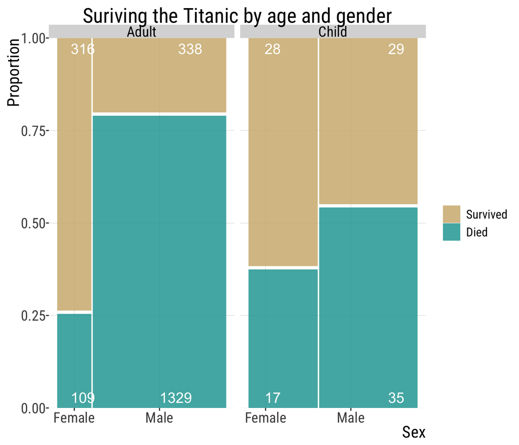

This is a mosaic plot. We will learn about it in our next topic. Code based on snippets from Y. Brandvain.

## Discuss

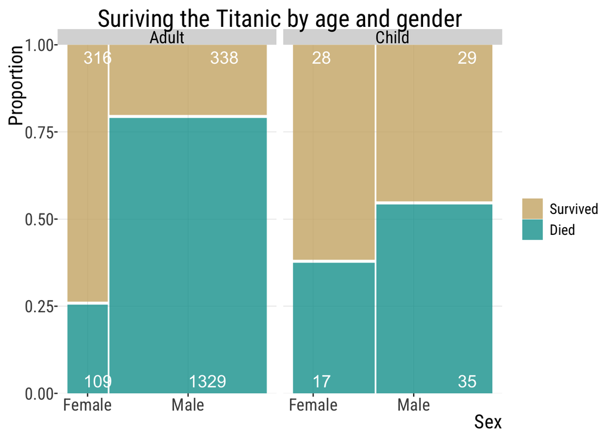

1. Variables? Types? Explanatory & response variables?
2. Describe the population this result came from…
3. How far would you generalize from this to “Women & Children 1st?”
4. Experimental or observational study?

> In statistics, a spurious relationship or **spurious correlation** is a mathematical relationship in which two or more events or variables are associated but **not causally related**, due to either *coincidence* or the *presence of a certain third, unseen factor* (referred to as a “common response variable”, **“confounding factor”**, or “lurking variable”). [Wikipedia Commons](https://en.wikipedia.org/wiki/Spurious_relationship)

Confounding Variables: unmeasured variable that changes in tandem with one or more of the measured variables, giving a false appearance of a causal association between the measured variables.

## Example

What could be happening here?

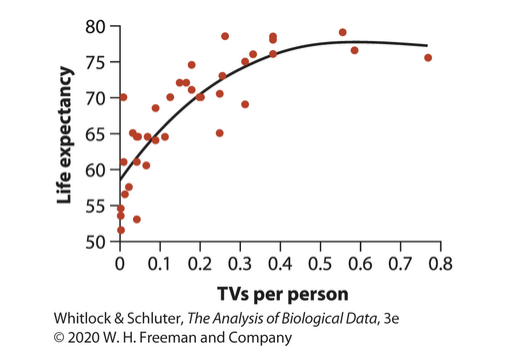

## Causal Inference

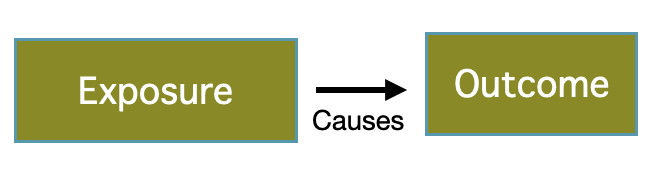

. . .

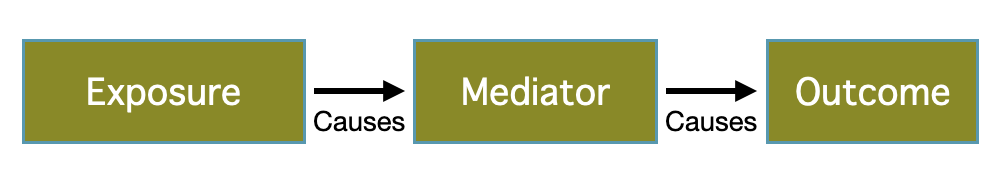

. . .

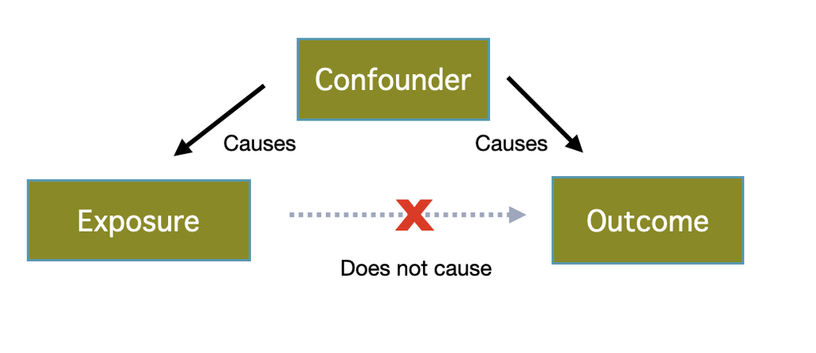

## Causal Inference

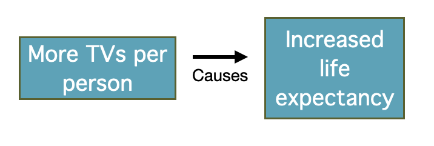

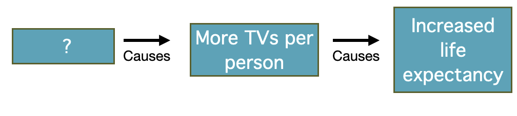

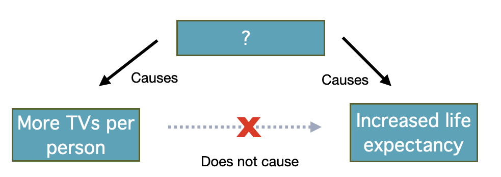

[figure not shown]

From Wikipedia Commons. Graphical model: Whereas a mediator is a factor in the causal chain (top), a confounder is a spurious factor incorrectly implying causation (bottom)

## Example 2

Consider a study showing (positive association) that people who ate more steaks can do more push-ups.

- Eating steaks could give people more muscle tone/strength OR
- A certain type of person may enjoy both eating steaks and building muscle OR
- Something else

**Questions:**

- Observational or experimental?
- Is this enough to show causation?

## Example 3

Consider a study showing that plants with fewer pests had greater biomass.

- Pests could decrease plant vigor OR
- Vigorous plants could fight off pests OR
- Something else

**Questions:**

- Observational or experimental?
- Is this enough to show causation?

## Observational studies cannot separate cause and effect

Simply observing the association (correlation) is not enough to infer causation, but could point to hypotheses which, hopefully, can be tested.

The main purpose of experimental studies is to disentangle these effects.

## But experiments can reveal causation

- Because researchers can randomly assign individuals to treatments, a well-executed experimental study removes confounds (except those that arise by chance!) and allows us to separate cause and effect !!!
- But be careful, experimental artifacts can introduce bias.
- For example, the mental boost of receiving a treatment may help people feel better, an example of the **placebo effect** – an improvement in medical condition that results form the physychological effects of treatment.
- Appropriate controls are critical to a good experiment.

. . .

Placebo (Latin): “I shall please”, from placeō, “I please”. Read Interleaf 6 for more on the placebo effect.

[figure not shown]

From: makeameme.org